# Atlantic PATH IBD analysis

# QIIME2 processing

## Initial quality checks

```bash
cd Future_IBD_samples
mkdir fastqc_Previous_Seqd/
mkdir fastqc_Run376
mkdir fastqc_Run377
fastqc -t 4 Previous_Seqd/*fastq.gz -o fastqc_Previous_Seqd/
fastqc -t 4 Run376/*fastq.gz -o fastqc_Run376/
fastqc -t 4 Run377/*fastq.gz -o fastqc_Run377/
multiqc fastqc_Previous_Seqd/ -f
mv multiqc_report.html multiqc_report_Previous_Seqd.html
rm -r multiqc_data/
multiqc fastqc_Run376/ -f
mv multiqc_report.html multiqc_report_Run376.html
rm -r multiqc_data/
multiqc fastqc_Run377/ -f
mv multiqc_report.html multiqc_report_Run377.html
rm -r multiqc_data/

cd ..
cd other_IBD

mkdir fastqc_Plate10102440/
mkdir fastqc_redos/
mkdir fastqc_Run218/
mkdir fastqc_Run223/
mkdir fastqc_Run225/
mkdir fastqc_Run232/
fastqc -t 4 rawdata_Plate10102440/*fastq.gz -o fastqc_Plate10102440/
fastqc -t 4 rawdata_redos/*fastq.gz -o fastqc_redos/
fastqc -t 4 rawdata_Run218/*fastq.gz -o fastqc_Run218/
fastqc -t 4 rawdata_Run223/*fastq.gz -o fastqc_Run223/
fastqc -t 4 rawdata_Run225/*fastq.gz -o fastqc_Run225/
fastqc -t 4 rawdata_Run232/*fastq.gz -o fastqc_Run232/
multiqc fastqc_Plate10102440/ -f
mv multiqc_report.html multiqc_report_Plate10102440.html
rm -r multiqc_data/
multiqc fastqc_redos/ -f
mv multiqc_report.html multiqc_report_redos.html
rm -r multiqc_data/
multiqc fastqc_Run218/ -f
mv multiqc_report.html multiqc_report_Run218.html
rm -r multiqc_data/
multiqc fastqc_Run223/ -f
mv multiqc_report.html multiqc_report_Run223.html
rm -r multiqc_data/
multiqc fastqc_Run225/ -f
mv multiqc_report.html multiqc_report_Run225.html
rm -r multiqc_data/
multiqc fastqc_Run232/ -f
mv multiqc_report.html multiqc_report_Run232.html
rm -r multiqc_data/
```

## Import and summarize

```bash
cd Future_IBD_samples

qiime tools import \
  --type SampleData[PairedEndSequencesWithQuality] \
  --input-path Previous_Seqd/ \
  --output-path reads_previous_seqd.qza \
  --input-format CasavaOneEightSingleLanePerSampleDirFmt
qiime demux summarize \
  --i-data reads_previous_seqd.qza  \
  --o-visualization summary_reads_previous_seqd.qzv

qiime tools import \
  --type SampleData[PairedEndSequencesWithQuality] \
  --input-path Run376/ \
  --output-path reads_Run376.qza \
  --input-format CasavaOneEightSingleLanePerSampleDirFmt
qiime demux summarize \
  --i-data reads_Run376.qza  \
  --o-visualization summary_reads_Run376.qzv

qiime tools import \
  --type SampleData[PairedEndSequencesWithQuality] \
  --input-path Run377/ \
  --output-path reads_Run377.qza \
  --input-format CasavaOneEightSingleLanePerSampleDirFmt
qiime demux summarize \
  --i-data reads_Run377.qza  \
  --o-visualization summary_reads_Run377.qzv

cd ..
cd other_IBD

qiime tools import \
  --type SampleData[PairedEndSequencesWithQuality] \
  --input-path rawdata_Plate10102440/ \
  --output-path reads_Plate10102440.qza \
  --input-format CasavaOneEightSingleLanePerSampleDirFmt
qiime demux summarize \
  --i-data reads_Plate10102440.qza  \
  --o-visualization summary_reads_Plate10102440.qzv

qiime tools import \
  --type SampleData[PairedEndSequencesWithQuality] \
  --input-path rawdata_redos/ \
  --output-path reads_redos.qza \
  --input-format CasavaOneEightSingleLanePerSampleDirFmt
qiime demux summarize \
  --i-data reads_redos.qza  \
  --o-visualization summary_reads_redos.qzv

qiime tools import \
  --type SampleData[PairedEndSequencesWithQuality] \
  --input-path rawdata_Run218/ \
  --output-path reads_Run218.qza \
  --input-format CasavaOneEightSingleLanePerSampleDirFmt
qiime demux summarize \
  --i-data reads_Run218.qza  \
  --o-visualization summary_reads_Run218.qzv

qiime tools import \
  --type SampleData[PairedEndSequencesWithQuality] \
  --input-path rawdata_Run223/ \
  --output-path reads_Run223.qza \
  --input-format CasavaOneEightSingleLanePerSampleDirFmt
qiime demux summarize \
  --i-data reads_Run223.qza  \
  --o-visualization summary_reads_Run223.qzv

qiime tools import \
  --type SampleData[PairedEndSequencesWithQuality] \
  --input-path rawdata_Run225/ \
  --output-path reads_Run225.qza \
  --input-format CasavaOneEightSingleLanePerSampleDirFmt
qiime demux summarize \
  --i-data reads_Run225.qza  \
  --o-visualization summary_reads_Run225.qzv

qiime tools import \
  --type SampleData[PairedEndSequencesWithQuality] \
  --input-path rawdata_Run232/ \
  --output-path reads_Run232.qza \
  --input-format CasavaOneEightSingleLanePerSampleDirFmt
qiime demux summarize \
  --i-data reads_Run232.qza  \
  --o-visualization summary_reads_Run232.qzv
```

## Cutadapt V4V5

```bash
#Decided to just move all samples/processing files to individual directories for each run so that the commands didn't need to be changed each time. These are each of the directories (they will be combined after DADA2):
Future_IBD_samples/previous_seqd_summary
Future_IBD_samples/Run376_processing
Future_IBD_samples/Run377_processing
other_IBD/Plate10102440_processing
other_IBD/redos_processing
other_IBD/Run218_processing
other_IBD/Run223_processing
other_IBD/Run225_processing
other_IBD/Run232_processing

qiime cutadapt trim-paired \
  --i-demultiplexed-sequences reads.qza \
  --p-cores 8 \
  --p-front-f GTGYCAGCMGCCGCGGTAA \
  --p-front-r CCGYCAATTYMTTTRAGTTT \
  --p-discard-untrimmed \
  --p-no-indels \
  --o-trimmed-sequences trimmed_reads.qza

qiime demux summarize \
  --i-data trimmed_reads.qza  \
  --o-visualization summary_trimmed_reads.qzv
```

## DADA2

```bash
mkdir dada2_out
qiime dada2 denoise-paired \
  --i-demultiplexed-seqs trimmed_reads.qza \
  --p-trunc-len-f 260 \
  --p-trunc-len-r 160 \
  --p-max-ee-f 2 \
  --p-max-ee-r 2 \
  --p-n-threads 8 \
  --o-table dada2_out/table.qza \
  --o-representative-sequences dada2_out/representative_sequences.qza \
  --o-denoising-stats dada2_out/stats.qza

qiime metadata tabulate \
  --m-input-file dada2_out/stats.qza \
  --o-visualization stats_dada2_out.qzv

qiime feature-table summarize \
  --i-table dada2_out/table.qza  \
  --o-visualization summary_dada2_out.qzv
```

## Merge tables

```bash
qiime feature-table merge \
  --i-tables Future_IBD_samples/previous_seqd_processing/dada2_out/table.qza \
  --i-tables Future_IBD_samples/Run376_processing/dada2_out/table.qza \
  --i-tables Future_IBD_samples/Run377_processing/dada2_out/table.qza \
  --i-tables other_IBD/Plate10102440_processing/dada2_out/table.qza \
  --i-tables other_IBD/redos_processing/dada2_out/table.qza \
  --i-tables other_IBD/Run218_processing/dada2_out/table.qza \
  --i-tables other_IBD/Run223_processing/dada2_out/table.qza \
  --i-tables other_IBD/Run225_processing/dada2_out/table.qza \
  --i-tables other_IBD/Run232_processing/dada2_out/table.qza \
  --o-merged-table merged_table.qza

qiime feature-table merge-seqs \
  --i-data Future_IBD_samples/previous_seqd_processing/dada2_out/representative_sequences.qza \
  --i-data Future_IBD_samples/Run376_processing/dada2_out/representative_sequences.qza \
  --i-data Future_IBD_samples/Run377_processing/dada2_out/representative_sequences.qza \
  --i-data other_IBD/Plate10102440_processing/dada2_out/representative_sequences.qza \
  --i-data other_IBD/redos_processing/dada2_out/representative_sequences.qza \
  --i-data other_IBD/Run218_processing/dada2_out/representative_sequences.qza \
  --i-data other_IBD/Run223_processing/dada2_out/representative_sequences.qza \
  --i-data other_IBD/Run225_processing/dada2_out/representative_sequences.qza \
  --i-data other_IBD/Run232_processing/dada2_out/representative_sequences.qza \
  --o-merged-data merged_representative_sequences.qza
```

## Classify

```bash
qiime feature-classifier classify-sklearn \
  --i-reads merged_representative_sequences.qza \
  --i-classifier /home/shared/taxa_classifiers/qiime2-2020.8_classifiers/silva-138-99-nb-classifier.qza \
  --p-n-jobs 12 \
  --output-dir taxa

qiime tools export \
  --input-path taxa/classification.qza \
  --output-path taxa
```

## Filter features

```bash
qiime feature-table filter-features \
  --i-table merged_table.qza \
  --p-min-frequency 5 \
  --p-min-samples 1 \
  --o-filtered-table table_filtered.qza

qiime feature-table summarize \
  --i-table table_filtered.qza \
  --o-visualization summary_table_filtered.qzv

qiime taxa filter-table \
  --i-table table_filtered.qza \
  --i-taxonomy taxa/classification.qza \
  --p-include d__ \
  --p-exclude mitochondria,chloroplast \
  --o-filtered-table table_filtered_contamination.qza

qiime feature-table summarize \
  --i-table table_filtered_contamination.qza \
  --o-visualization summary_table_filtered_contamination.qzv
```

## Filter

*Not rarefying or removing samples with low numbers of reads*

```bash
qiime feature-table filter-seqs \
  --i-data merged_representative_sequences.qza \
  --i-table table_filtered_contamination.qza \
  --o-filtered-data  representative_sequences_filtered_contamination.qza
```

## Insert sequences into tree

```bash
qiime fragment-insertion sepp \
  --i-representative-sequences representative_sequences_filtered_contamination.qza \
  --i-reference-database /home/robyn/tools/sepp/sepp-refs-silva-128.qza \
  --o-tree insertion_tree.qza \
  --o-placements insertion_placements.qza \
  --p-threads 12
```

## Get rarefaction curves

```bash
qiime diversity alpha-rarefaction \
  --i-table table_filtered_contamination.qza \
  --p-max-depth 131945 \
  --p-steps 20 \
  --p-metrics 'observed_features' \
  --o-visualization rarefaction_curves.qzv
```

Screenshot from the QIIME2 website:

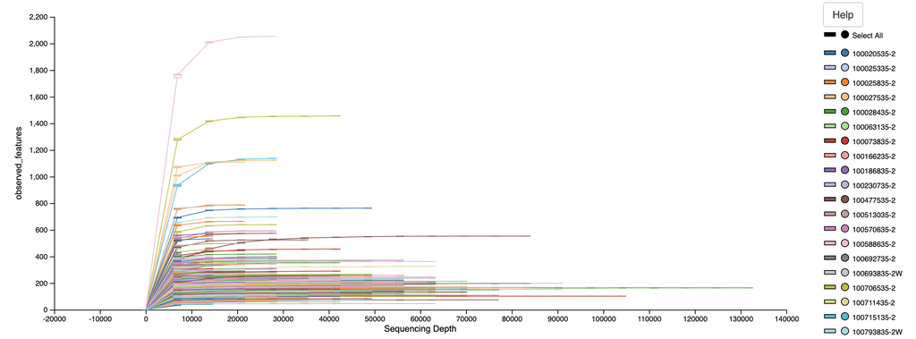

## Export all files

```bash
qiime tools export \
  --input-path representative_sequences_filtered_contamination.qza \
  --output-path exports

sed -i -e '1 s/Feature/#Feature/' -e '1 s/Taxon/taxonomy/' taxa/taxonomy.tsv

qiime tools export \
  --input-path table_filtered_contamination.qza \
  --output-path exports

biom add-metadata \
  -i exports/feature-table.biom \
  -o exports/feature-table_w_tax.biom \
  --observation-metadata-fp taxa/taxonomy.tsv \
  --sc-separated taxonomy

biom convert \
  -i exports/feature-table_w_tax.biom \
  -o exports/feature-table_w_tax.txt \
  --to-tsv \
  --header-key taxonomy

qiime tools export \
  --input-path insertion_tree.qza \
  --output-path exports
```

# Basic summary

No filtering low depth samples or removal of ASVs (aside from what was very low abundance in QIIME2).

## Sort metadata

Metadata is currently in three different tables: original, baseline and followup. Some of the variable names are the same between these, some are not. I’ve identified which match between them in the variable labels file, and have added a column with a new name for each. Now to add all of the metadata to a single file and check, adding only the data for samples that we actually have.

```python
variable_labels = pd.read_csv('/Users/robynwright/Documents/OneDrive/Langille_Lab_postdoc/AtPATH_IBD/Metadata/sorting/variable_labels.csv', header=0)
baseline_data = pd.read_csv('/Users/robynwright/Documents/OneDrive/Langille_Lab_postdoc/AtPATH_IBD/Metadata/sorting/baseline_data.csv', header=0)
followup_data = pd.read_csv('/Users/robynwright/Documents/OneDrive/Langille_Lab_postdoc/AtPATH_IBD/Metadata/sorting/followup_data.csv', header=0)
original_data = pd.read_csv('/Users/robynwright/Documents/OneDrive/Langille_Lab_postdoc/AtPATH_IBD/Metadata/sorting/original_data.csv', header=0)
label_dict = {}

for row in variable_labels.index.values:
  followup, baseline, original, new = variable_labels.loc[row, ['variable_name_followup', 'variable_name_baseline', 'variable_name_original', 'new_name']].values
  if isinstance(followup, str): label_dict[followup] = new
  if isinstance(baseline, str): label_dict[baseline] = new
  if isinstance(original, str): label_dict[original] = new

new_labels = variable_labels.loc[:, 'new_name'].values
baseline_data.rename(columns=label_dict, inplace=True)
followup_data.rename(columns=label_dict, inplace=True)
original_data.rename(columns=label_dict, inplace=True)
datasets = [baseline_data, followup_data, original_data]

variable_labels['BASELINE_VARIABLES'] = ''
variable_labels['FOLLOWUP_VARIABLES'] = ''
variable_labels['ORIGINAL_VARIABLES'] = ''
dataset_names = ['BASELINE_VARIABLES', 'FOLLOWUP_VARIABLES', 'ORIGINAL_VARIABLES']
variable_labels.set_index('new_name', inplace=True)

for label in new_labels:
  for d in range(len(datasets)):
    data = datasets[d]
    if label not in data.columns:
      variable_labels.loc[label, dataset_names[d]] = 'Not in dataset'
      continue
    all_vals = list(data.loc[:, label])
    all_vals = [str(val) for val in all_vals]
    all_vals = set(all_vals)
    this_variable = ''
    for val in all_vals:
      if this_variable != '': this_variable += ', '+str(val)
      else: this_variable += str(val)
    variable_labels.loc[label, dataset_names[d]] = this_variable

variable_labels.to_csv('/Users/robynwright/Documents/OneDrive/Langille_Lab_postdoc/AtPATH_IBD/Metadata/sorting/sorted_variable_labels.csv')

baseline_data.loc[:, 'DATASET'] = 'baseline'
followup_data.loc[:, 'DATASET'] = 'followup'
original_data.loc[:, 'DATASET'] = 'original'

new_columns = set(['DATASET']+list(new_labels))
count = 0
datasets = [baseline_data, followup_data, original_data]

for data in datasets:
  for col in new_columns:
    if col not in data.columns:
      data[col] = 'NA'
  if count == 0:
    combined_data = data.loc[:, new_columns].set_index('SALIVA')
  else:
    combined_data = pd.concat([combined_data, data.loc[:, new_columns].set_index('SALIVA')])
  count += 1

combined_data.to_csv('/Users/robynwright/Documents/OneDrive/Langille_Lab_postdoc/AtPATH_IBD/Metadata/sorting/sorted_metadata.csv')
```

Get original fastq file names:

```python
import os
import pickle

folders = ['Plate10102440_processing', 'redos_processing', 'Run218_processing', 'Run223_processing', 'Run225_processing', 'Run232_processing']
all_fastq = []
for folder in folders:
  contents = os.listdir(folder)
  for file in contents:
    if 'rawdata' in file:
      fastq = os.listdir(folder+'/'+file)
      all_fastq = all_fastq+fastq

for f in range(len(all_fastq)):
  all_fastq[f] = all_fastq[f].split('_')[0]

all_fastq = list(set(all_fastq))
print(len(all_fastq))

with open('all_file_names.list', 'wb') as f:
    pickle.dump(all_fastq, f)
```

## Import data

Sort data (matching sample names between the feature table and reducing the metadata table to only include samples that are in the feature table):

```python
metadata = pd.read_csv('/Users/robynwright/Documents/OneDrive/Langille_Lab_postdoc/AtPATH_IBD/Metadata/sorting/sorted_metadata.csv', header=0)
#remove samples from extraction 16 and check they didn't have additional metadata
metadata_16rem = metadata.loc[metadata.loc[:, 'EXTRACTION_NUMBER'] != 'Extraction.16'].set_index('SALIVA')
metadata_16 = metadata.loc[metadata.loc[:, 'EXTRACTION_NUMBER'] == 'Extraction.16'].set_index('SALIVA')
ex16_samples, columns = list(metadata_16.index.values), list(metadata_16.columns)
for sample in ex16_samples:
  for column in columns:
    if metadata_16.loc[sample, column] != 'NA' and metadata_16.loc[sample, column] != 'nan':
      if metadata_16rem.loc[sample, column] == 'NA' or metadata_16rem.loc[sample, column] == 'nan': metadata_16rem.loc[sample, column] = metadata_16.loc[sample, column]
metadata = metadata_16rem.reset_index()

#some of the sample names open as floats so we need to change this (we can't just covert to integers and then floats as some of them can't be due to hyphenated ends)
metadata['SAMPLE_NAME_FT'] = metadata['SAMPLE_NAME_FT'].astype(str)
for row in metadata.index.values:
  if '.0' in metadata.loc[row, 'SAMPLE_NAME_FT']:
    metadata.loc[row, 'SAMPLE_NAME_FT'] = str(int(float(metadata.loc[row, 'SAMPLE_NAME_FT'])))
metadata = metadata.set_index('SALIVA')
metadata.index = metadata.index.map(str)

#check for duplicate saliva samples
saliva, duplicates = [], []
for row in list(metadata.index.values):
  if row in saliva: duplicates.append(row)
  else: saliva.append(row)

#if the saliva samples don't have an associated sequenced sample, remove them from the metadata table, but first check whether there is additional metadata there.
metadata = metadata.reset_index()
not_keeping = []
for duplicate in duplicates:
  keep, not_keep = [], []
  for row in metadata.index.values:
    if metadata.loc[row, 'SALIVA'] == duplicate:
      if metadata.loc[row, 'SAMPLE_NAME_FT'] == 'nan':
        not_keeping.append(row), not_keep.append(row)
      else:
        keep.append(row)
  if not_keep != []:
    for nk in not_keep:
      for column in columns:
        if metadata.loc[nk, column] != 'NA' and metadata.loc[nk, column] != 'nan':
          for k in keep:
            if metadata.loc[k, column] == 'NA' or metadata.loc[k, column] == 'nan':
              metadata.loc[k, column] = metadata.loc[nk, column]
metadata = metadata.drop(not_keeping, axis=0)

#Now remove those samples that aren't to do with IBD and rename those that are multiple cancers (including IBD) to only IBD
metadata = metadata.set_index('SALIVA')
keeping = []
for row in list(metadata.index.values):
  if not isinstance(metadata.loc[row, 'GROUP'], str):
    if row != 'sterile-water': keeping.append(row)
  elif 'IBD' in metadata.loc[row, 'GROUP']:
    if metadata.loc[row, 'GROUP'] != 'IBD': metadata.loc[row, 'GROUP'] = 'IBD'
    if row != 'sterile-water': keeping.append(row)
metadata = metadata.loc[keeping, :]

#drop any duplicates that have the same sample name and dataset name and check how many duplicates we have now
metadata = metadata.drop_duplicates(subset=['SAMPLE_NAME_FT', 'DATASET'])
if metadata.index.name != 'SALIVA': metadata = metadata.set_index('SALIVA')
saliva, duplicates = [], []
for row in list(metadata.index.values):
  if row in saliva: duplicates.append(row)
  else: saliva.append(row)

#here we are checking the dataset, sample name, caseid and extraction number of each duplicate. If each instance of the duplicates caseid's are identical then these were resequenced versions of samples that didn't work well the first round, so we are keeping the sample names that have '-2' on the end. We have three samples that were sequenced in duplicate accidentally because AtPATH resent them, so here we are just adding 'dup' to the end, and this is also added to the appropriate samples in the feature table (basing this on the ones that aren't the same number of reads as in the first round of analysis). Apparently only one of these was duplicated in the feature table (probably QIIME2 did something with the samples that had the same name), so I've just removed the 'PS' from one of them so that they'll match the samples that don't have 'dup' on the end. If I decide to look at the duplicates at some point then I'll cross this bridge then.
if metadata.index.name == 'SALIVA': metadata = metadata.reset_index()
not_keeping = []
for duplicate in duplicates:
  r, dataset, sn, caseid, extract = [], [], [], [], []
  for row in metadata.index.values:
    if metadata.loc[row, 'SALIVA'] == duplicate:
      r.append(row), dataset.append(metadata.loc[row, 'DATASET']), sn.append(metadata.loc[row, 'SAMPLE_NAME_FT']), caseid.append(metadata.loc[row, 'CASEID']), extract.append(metadata.loc[row, 'EXTRACTION_NUMBER'])
  if caseid[0] == caseid[1]:
    if '-2' not in sn[0]: not_keeping.append(r[0])
    else: not_keeping.append(r[1])
  else:
    for e in range(len(extract)):
      if extract[e] != 'Extraction.18':
        not_keeping.append(r[e])
metadata = metadata.drop(not_keeping, axis=0)
metadata = metadata.loc[metadata.loc[:, 'GROUP'] == 'IBD']
metadata = metadata.set_index('SALIVA')
metadata.to_csv(save_path+'metadata_check.csv')
metadata.index = metadata.index.map(str)

#now get the feature table
ft = pd.read_csv('/Users/robynwright/Documents/OneDrive/Langille_Lab_postdoc/AtPATH_IBD/exports/feature-table_w_tax.txt', index_col=0, header=0, sep='\t')
ft.columns = ft.columns.map(str)

#and check whether we have all of the samples from the metadata table in the feature table - some have two different names by splitting with '/', so I'm just taking the first of these and renaming the column in the metadata table.
if metadata.index.name != 'SAMPLE_NAME_FT': metadata = metadata.reset_index().set_index('SAMPLE_NAME_FT')
sample_rename = {}
drop = []
for sample in metadata.index.values:
  if sample not in ft.columns:
    if '/' in sample:
      sample1 = sample.split(' /')[0]
      sample_rename[sample] = sample1
    else:
      drop.append(sample)
metadata = metadata.rename(index=sample_rename)
metadata = metadata.drop(drop, axis=0)

#now reducing the feature table to these samples
ft = ft.loc[:, list(metadata.index.values)+['taxonomy']]

#renaming the future IBD samples
for sample in metadata.index.values:
  if 'F' in metadata.loc[sample, 'CASEID']:
    metadata.loc[sample, 'GROUP'] = 'FUTURE_IBD'

#and saving the files
metadata.to_csv(save_path+'metadata_reduced.csv')
ft_reduced.to_csv(save_path+'ft_1_reduced_metadata.csv')
```

Apparently this still wasn’t enough to make sure that all of the sample names were the same between the metadata table and the featrue table, so one final check:

```python
metadata_fn = save_path+'metadata_reduced.csv'
ft_fn = save_path+'ft_1_reduced_metadata.csv'
metadata = pd.read_csv(metadata_fn, index_col=0, header=0)
ft = pd.read_csv(ft_fn, index_col=0, header=0)

samples_md, samples_ft, samples_keep = list(metadata.index.values), list(ft.columns), []
not_md, not_ft = [], []
for smd in samples_md:
  if smd not in samples_ft:
    not_md.append(smd)
  else:
    samples_keep.append(smd)
for sft in samples_ft:
  if sft not in samples_md:
    not_ft.append(sft)

metadata = metadata.loc[samples_keep, :]
metadata['SDC_GENDER'] = metadata['SDC_GENDER'].astype(float)
metadata['SDC_GENDER'] = metadata['SDC_GENDER'].astype(int)
ft = ft.loc[:, samples_keep+['taxonomy']]
metadata.to_csv(save_path+'metadata_reduced_ft.csv')
ft.to_csv(save_path+'ft_2_reduced_metadata.csv')
```

## Summarise by metadata variables

Show all samples, samples grouped by healthy/IBD/future IBD  
Groups:  
- IBD  
- FUTURE_IBD

```python
metadata_fn = save_path+'metadata_reduced_ft.csv'
ft_fn = save_path+'ft_2_reduced_metadata.csv'
```

```python
metadata = pd.read_csv(metadata_fn, index_col=0, header=0)
metadata = metadata.reset_index().set_index('SALIVA')
ft = pd.read_csv(ft_fn, index_col=0, header=0).drop('taxonomy', axis=1)
metadata_group = metadata.set_index('GROUP')
```

### Gender

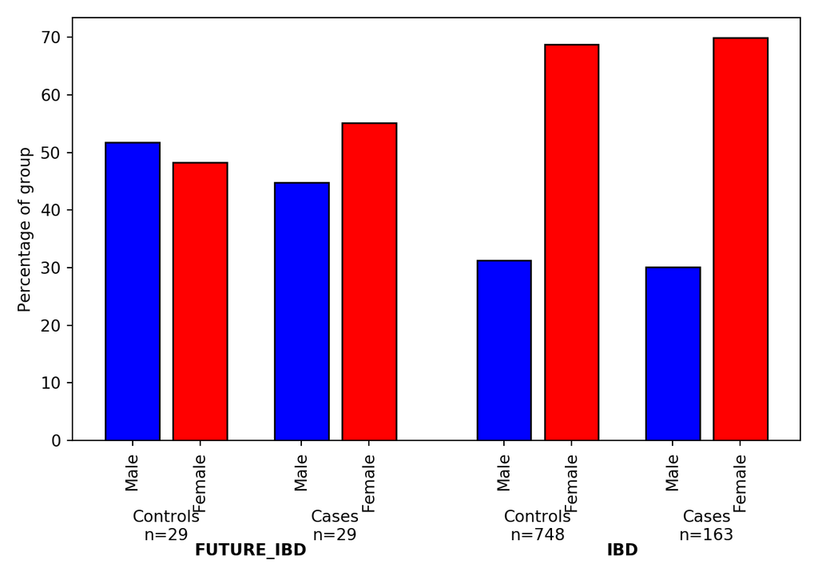

```python
def plot_two_category_discrete(category_dict, category, md, percent=False):
  groups = list(set(md.index.values))
  count = 0
  plot, x, names, colors = [], [1, 2, 3.5, 4.5, 6.5, 7.5, 9, 10], [], ['b', 'r', 'b', 'r', 'b', 'r', 'b', 'r']
  labels = ['Controls\nn=', 'Cases\nn=', 'Controls\nn=', 'Cases\nn=']
  for group in groups:
    md_group = pd.DataFrame(md.loc[group, [category, 'CASE_CONTROL']]).reset_index()
    g1_case, g1_control, g2_case, g2_control = 0, 0, 0, 0
    cats = [cat for cat in category_dict]
    for row in md_group.index.values:
      if md_group.loc[row, 'CASE_CONTROL'] == 0 and md_group.loc[row, category] == cats[0]:
        g1_control += 1
      elif md_group.loc[row, 'CASE_CONTROL'] == 1 and md_group.loc[row, category] == cats[0]:
        g1_case += 1
      elif md_group.loc[row, 'CASE_CONTROL'] == 0 and md_group.loc[row, category] == cats[1]:
        g2_control += 1
      elif md_group.loc[row, 'CASE_CONTROL'] == 1 and md_group.loc[row, category] == cats[1]:
        g2_case += 1
    if count == 0:
      labels[1] += str(g1_case+g2_case)
      labels[0] += str(g1_control+g2_control)
    elif count == 1:
      labels[3] += str(g1_case+g2_case)
      labels[2] += str(g1_control+g2_control)
    count += 1
    if percent:
      perc_g1_case, perc_g1_control, perc_g2_case, perc_g2_control = (g1_case/(g1_case+g2_case))*100, (g1_control/(g1_control+g2_control))*100, (g2_case/(g1_case+g2_case))*100, (g2_control/(g1_control+g2_control))*100
      g1_case, g1_control, g2_case, g2_control = perc_g1_case, perc_g1_control, perc_g2_case, perc_g2_control
    plot = plot+[g1_control, g2_control, g1_case, g2_case]
    names = names+[category_dict[cats[0]], category_dict[cats[1]], category_dict[cats[0]], category_dict[cats[1]]]
  ax1 = plt.subplot(111)
  ax1.bar(x, plot, color=colors, edgecolor='k')
  plt.xticks(x, names, rotation=90)
  if percent:
    ax1.set_ylabel('Percentage of group')
  else:
    ax1.set_ylabel('Number of participants')
  text = [1.5, 4, 7, 9.5]
  for a in range(len(text)):
    ax1.text(text[a], -15, labels[a], ha='center', va='center')
  text = [2.75, 8.25]
  for g in range(len(groups)):
    ax1.text(text[g], -20, groups[g], ha='center', fontweight='bold')
  return

plot_two_category_discrete({1:'Male', 2:'Female'}, 'SDC_GENDER', metadata_group, percent=True)
plt.tight_layout()
plt.show()
```

### Age

```python
def adjacent_values(vals, q1, q3):
    upper_adjacent_value = q3 + (q3 - q1) * 1.5
    upper_adjacent_value = np.clip(upper_adjacent_value, q3, vals[-1])

    lower_adjacent_value = q1 - (q3 - q1) * 1.5
    lower_adjacent_value = np.clip(lower_adjacent_value, vals[0], q1)
    return lower_adjacent_value, upper_adjacent_value

def add_lines(dt, num, ax):
  quartile1, medians, quartile3 = np.percentile(dt, [25, 50, 75])
  whiskers = adjacent_values(dt, quartile1, quartile3)
  whiskersMin, whiskersMax = whiskers[0], whiskers[1]
  inds = np.arange(num, num + 1)

  ax.scatter(inds, medians, marker='o', color='white', s=30, zorder=3)
  ax.vlines(inds, quartile1, quartile3, color='k', linestyle='-', lw=5)
  ax.vlines(inds, whiskersMin, whiskersMax, color='k', linestyle='-', lw=1)
  return

def plot_two_category_continuous(category, md, ax=False):
  groups = list(set(md.index.values))
  x, names, colors = [1, 2, 3, 4], [], ['#CB4335', '#F1C40F', '#CB4335', '#F1C40F']
  labels = ['Controls\nn=', 'Cases\nn=', 'Controls\nn=', 'Cases\nn=']
  data = []
  count = 0
  for group in groups:
    md_group = pd.DataFrame(md.loc[group, [category, 'CASE_CONTROL']]).reset_index()
    case, control = [], []
    for row in md_group.index.values:
      if md_group.loc[row, 'CASE_CONTROL'] == 0:
        control.append(md_group.loc[row, category])
      elif md_group.loc[row, 'CASE_CONTROL'] == 1:
        case.append(md_group.loc[row, category])
    if count == 0:
      labels[0] = labels[0]+str(len(control))
      labels[1] = labels[1]+str(len(case))
    else:
      labels[2] = labels[2]+str(len(control))
      labels[3] = labels[3]+str(len(case))
    count += 1
    data.append(control)
    data.append(case)
  if ax == False:
    ax = plt.subplot(111)
  parts = ax.violinplot(data, showmeans=False, showmedians=False, showextrema=False)
  count = 0
  for pc in parts['bodies']:
    pc.set_facecolor(colors[count])
    pc.set_edgecolor('black')
    pc.set_alpha(1)
    count += 1
  for a in range(len(data)):
    add_lines(data[a], a+1, ax)
  plt.sca(ax)
  plt.xticks(x, labels)
  text = [0.225, 0.775]
  for g in range(len(groups)):
    ax.text(text[g], -0.15, groups[g], ha='center', fontweight='bold', transform=ax.transAxes)
  return

metadata_group = metadata_group.reset_index()
for row in metadata_group.index.values:
  if isinstance(metadata_group.loc[row, 'SDC_AGE_CALC'], float):
    age = metadata_group.loc[row, 'SDC_AGE_CALC']
    if np.isnan(age):
      dob = int(metadata_group.loc[row, 'SDC_DOB'])
      qx = int(metadata_group.loc[row, 'ADM_QX_COMPLETION'].split('/')[-1])
      age = qx-dob
      metadata_group.loc[row, 'SDC_AGE_CALC'] = age
metadata_group = metadata_group.set_index('GROUP')

plot_two_category_continuous('SDC_AGE_CALC', metadata_group)
```

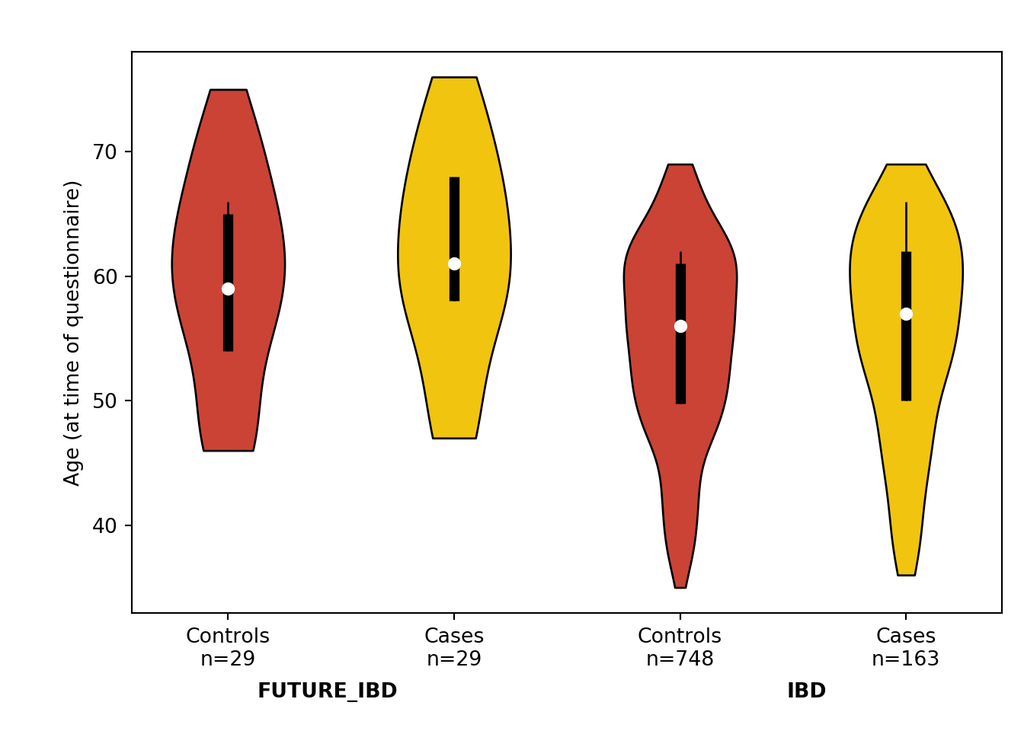

```python
plt.ylabel('Age (at time of questionnaire)')
plt.tight_layout()
plt.show()
```

### Rarefaction curves

Using the curves calculated by QIIME2 & saved to csv

```python
curves = pd.read_csv('/Users/robynwright/Documents/OneDrive/Langille_Lab_postdoc/AtPATH_IBD/rarefaction_curves_observed_features.csv', header=0, index_col=0)
curves = curves.loc[ft.columns, :]
col_names = curves.columns
col_rename = {}
for col in col_names:
  col_rename[col] = col.split('_')[0].split('-')[1]
curves = curves.rename(columns=col_rename)
curves.columns = curves.columns.map(int)
curves = curves.groupby(by=curves.columns, axis=1).mean()

metadata = pd.read_csv(metadata_fn, index_col=0, header=0)

groups, case_control = {}, {}
for row in metadata.index.values:
  groups[row] = metadata.loc[row, 'GROUP']
  case_control[row] = metadata.loc[row, 'CASE_CONTROL']

ax1 = plt.subplot(211)
ax2 = plt.subplot(212)
curves.transpose().plot(ax=ax1, legend=False)
curves.transpose().plot(ax=ax2, legend=False)
plt.sca(ax2)
plt.xlim([-1000, 20000])
```

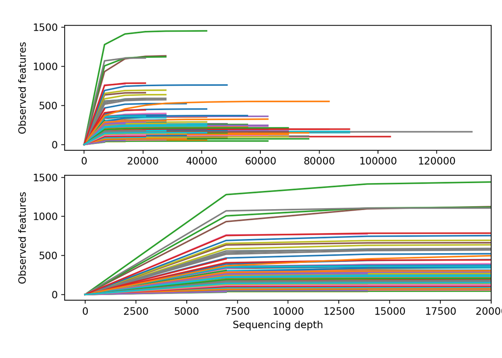

```python
plt.xlabel('Sequencing depth')
plt.ylabel('Observed features')
plt.sca(ax1)
plt.ylabel('Observed features')
plt.show()
```

### Number of reads

Note that at this point no samples have been removed and the only ASVs that were removed were the ones that were present at less than 5 total reads.

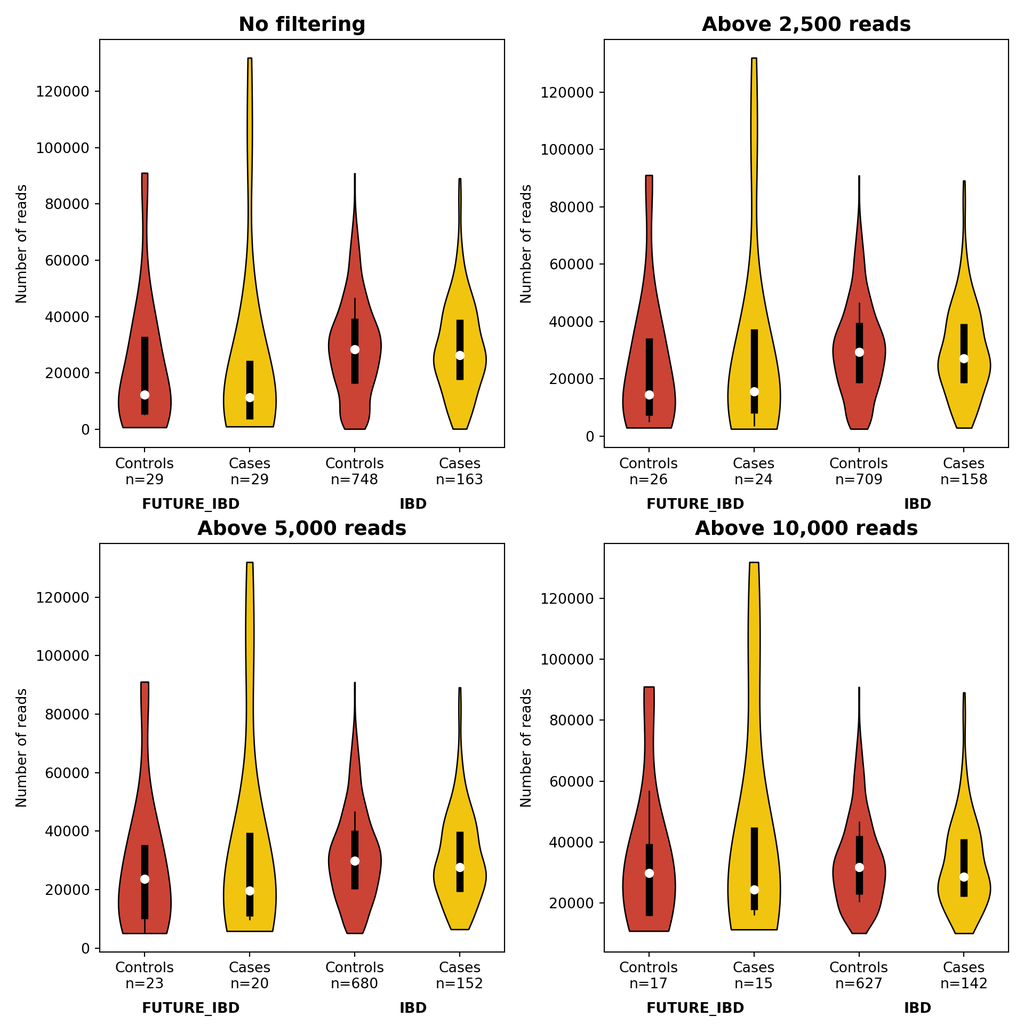

```python
metadata = pd.read_csv(metadata_fn, index_col=0, header=0)
filtering = [0, 2500, 5000, 10000]

reads = ft.sum(axis=0)
groups, case_control = {}, {}
for row in metadata.index.values:
  groups[row] = metadata.loc[row, 'GROUP']
  case_control[row] = metadata.loc[row, 'CASE_CONTROL']
metadata = metadata.reset_index().set_index('SALIVA')

plt.figure(figsize=(10,10))
axis = [plt.subplot(221), plt.subplot(222), plt.subplot(223), plt.subplot(224)]
titles = ['No filtering', 'Above 2,500 reads', 'Above 5,000 reads', 'Above 10,000 reads']
for a in range(len(axis)):
  reads_keeping = reads >= filtering[a]
  ft_reduced = ft.loc[:, reads_keeping]
  dropping = list(ft_reduced.index.values)
  ft_reduced = ft_reduced.transpose()
  ft_reduced['Reads'] = ft_reduced.sum(axis=1)
  ft_reduced.drop(dropping, axis=1, inplace=True)
  ft_reduced['GROUP'] = ''
  ft_reduced['CASE_CONTROL'] = ''
  for row in ft_reduced.index.values:
    try:
      ft_reduced.loc[row, 'GROUP'] = groups[row]
      ft_reduced.loc[row, 'CASE_CONTROL'] = case_control[row]
    except:
      ft_reduced.loc[row, 'GROUP'] = groups[row.split('-')[0]]
      ft_reduced.loc[row, 'CASE_CONTROL'] = case_control[row.split('-')[0]]
  ft_reduced = ft_reduced.set_index('GROUP')
  plot_two_category_continuous('Reads', ft_reduced, ax=axis[a])
  axis[a].set_ylabel('Number of reads')
  axis[a].set_title(titles[a], fontsize=14, fontweight='bold')

plt.tight_layout()
plt.show()
```

### Number of ASVs

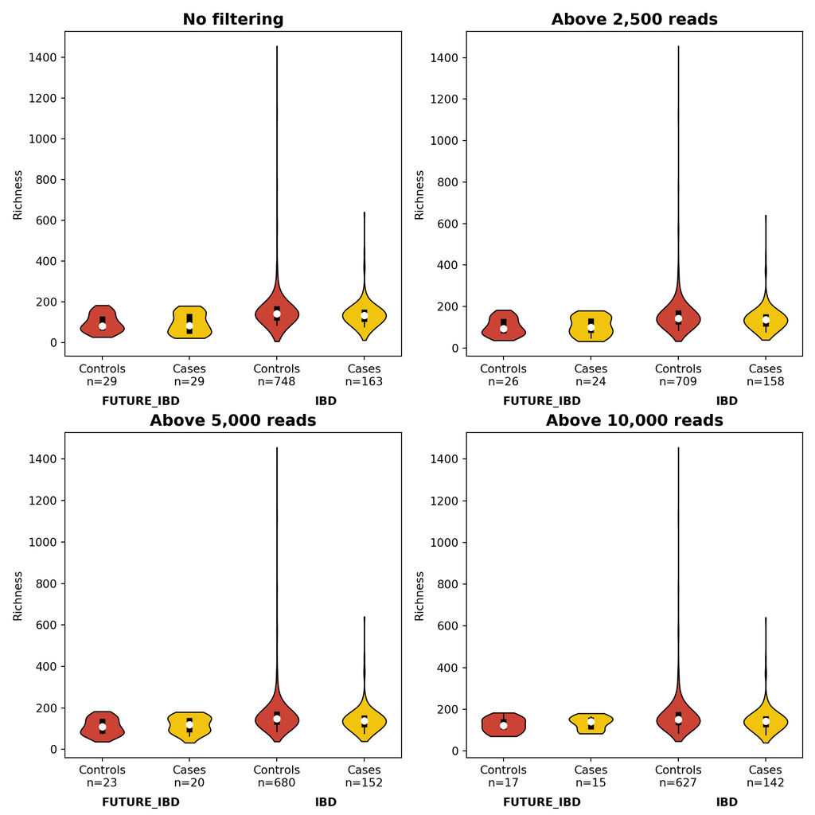

```python
plt.figure(figsize=(10,10))
axis = [plt.subplot(221), plt.subplot(222), plt.subplot(223), plt.subplot(224)]
titles = ['No filtering', 'Above 2,500 reads', 'Above 5,000 reads', 'Above 10,000 reads']
for a in range(len(axis)):
  reads_keeping = reads >= filtering[a]
  ft_reduced = ft.loc[:, reads_keeping]
  dropping = list(ft_reduced.index.values)
  rich = pd.DataFrame(ft_reduced)
  rich[rich > 0] = 1
  ft_reduced = ft_reduced.transpose()
  ft_reduced['Diversity'] = rich.sum(axis=0)
  ft_reduced.drop(dropping, axis=1, inplace=True)
  ft_reduced['GROUP'] = ''
  ft_reduced['CASE_CONTROL'] = ''
  for row in ft_reduced.index.values:
    try:
      ft_reduced.loc[row, 'GROUP'] = groups[row]
      ft_reduced.loc[row, 'CASE_CONTROL'] = case_control[row]
    except:
      ft_reduced.loc[row, 'GROUP'] = groups[row.split('-')[0]]
      ft_reduced.loc[row, 'CASE_CONTROL'] = case_control[row.split('-')[0]]
  ft_reduced = ft_reduced.set_index('GROUP')
  plot_two_category_continuous('Diversity', ft_reduced, ax=axis[a])
  axis[a].set_ylabel('Richness')
  axis[a].set_title(titles[a], fontsize=14, fontweight='bold')

plt.tight_layout()
plt.show()
```

### Shannon

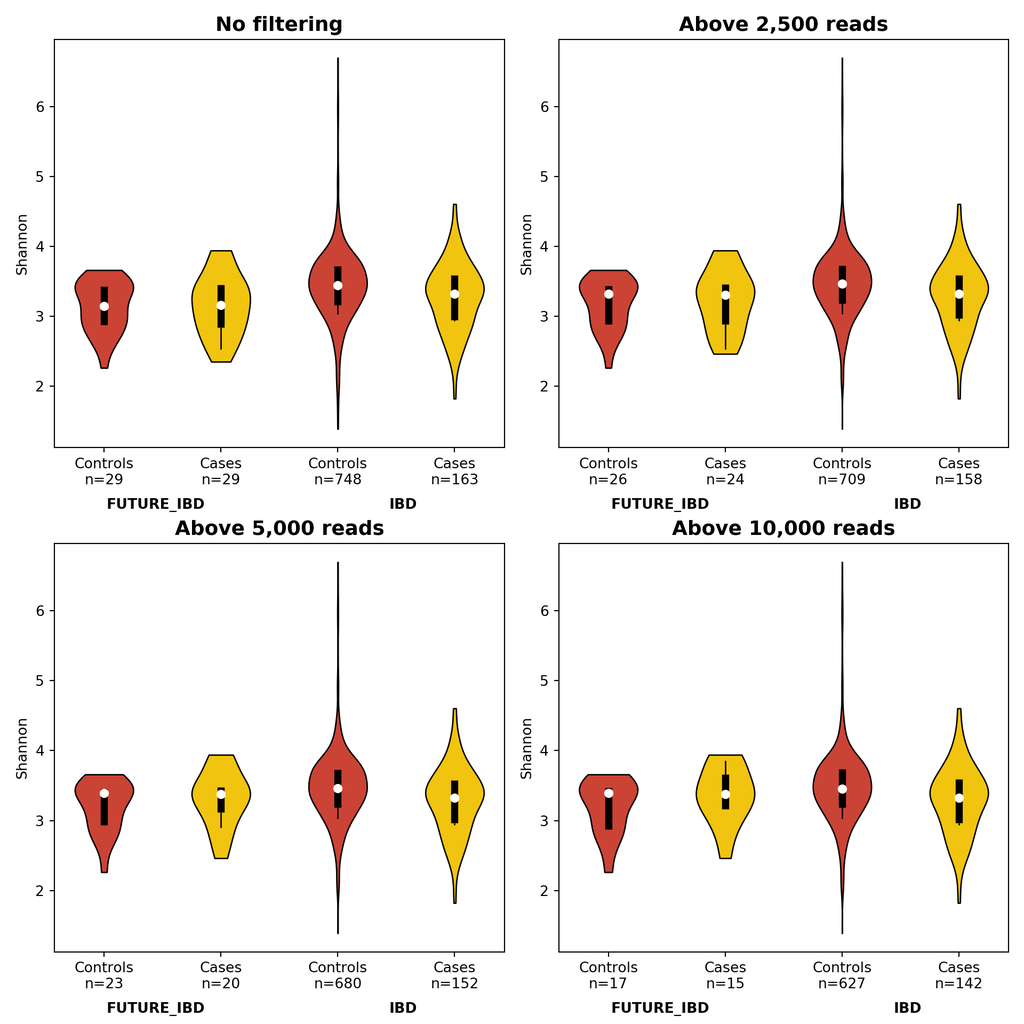

```python
plt.figure(figsize=(10,10))
axis = [plt.subplot(221), plt.subplot(222), plt.subplot(223), plt.subplot(224)]
titles = ['No filtering', 'Above 2,500 reads', 'Above 5,000 reads', 'Above 10,000 reads']
for a in range(len(axis)):
  reads_keeping = reads >= filtering[a]
  ft_reduced = ft.loc[:, reads_keeping]
  dropping = list(ft_reduced.index.values)
  div = []
  for column in ft_reduced.columns:
    sample = list(ft_reduced.loc[:, column])
    div.append(get_diversity('Shannon', sample))
  ft_reduced = ft_reduced.transpose()
  ft_reduced['Diversity'] = div
  ft_reduced.drop(dropping, axis=1, inplace=True)
  ft_reduced['GROUP'] = ''
  ft_reduced['CASE_CONTROL'] = ''
  for row in ft_reduced.index.values:
    try:
      ft_reduced.loc[row, 'GROUP'] = groups[row]
      ft_reduced.loc[row, 'CASE_CONTROL'] = case_control[row]
    except:
      ft_reduced.loc[row, 'GROUP'] = groups[row.split('-')[0]]
      ft_reduced.loc[row, 'CASE_CONTROL'] = case_control[row.split('-')[0]]
  ft_reduced = ft_reduced.set_index('GROUP')
  plot_two_category_continuous('Diversity', ft_reduced, ax=axis[a])
  axis[a].set_ylabel('Shannon')
  axis[a].set_title(titles[a], fontsize=14, fontweight='bold')

plt.tight_layout()
plt.show()
```

### Simpsons

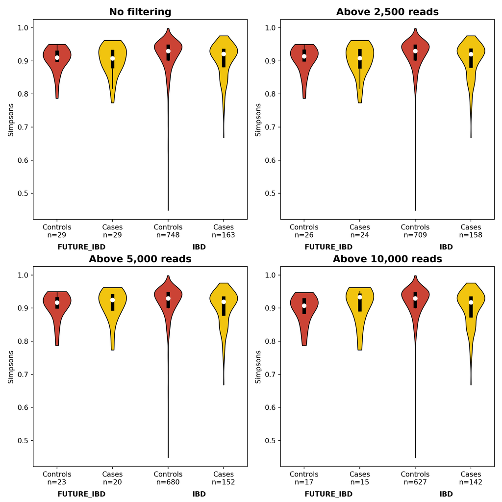

```python
plt.figure(figsize=(10,10))
axis = [plt.subplot(221), plt.subplot(222), plt.subplot(223), plt.subplot(224)]
titles = ['No filtering', 'Above 2,500 reads', 'Above 5,000 reads', 'Above 10,000 reads']
for a in range(len(axis)):
  reads_keeping = reads >= filtering[a]
  ft_reduced = ft.loc[:, reads_keeping]
  dropping = list(ft_reduced.index.values)
  div = []
  for column in ft_reduced.columns:
    sample = list(ft_reduced.loc[:, column])
    div.append(get_diversity('Simpsons', sample))
  ft_reduced = ft_reduced.transpose()
  ft_reduced['Diversity'] = div
  ft_reduced.drop(dropping, axis=1, inplace=True)
  ft_reduced['GROUP'] = ''
  ft_reduced['CASE_CONTROL'] = ''
  for row in ft_reduced.index.values:
    try:
      ft_reduced.loc[row, 'GROUP'] = groups[row]
      ft_reduced.loc[row, 'CASE_CONTROL'] = case_control[row]
    except:
      ft_reduced.loc[row, 'GROUP'] = groups[row.split('-')[0]]
      ft_reduced.loc[row, 'CASE_CONTROL'] = case_control[row.split('-')[0]]
  ft_reduced = ft_reduced.set_index('GROUP')
  plot_two_category_continuous('Diversity', ft_reduced, ax=axis[a])
  axis[a].set_ylabel('Simpsons')
  axis[a].set_title(titles[a], fontsize=14, fontweight='bold')

plt.tight_layout()
plt.show()
```

# Ordination plots

## Without filtering

Not normalised at all or had any low depth samples removed.  
Reduce the number of features in the feature table (so we don’t run out of memory calculating PHILR distances) - and use this for all plots so they’re all based on the same number of features:

```python
ft_sum = ft.sum(axis=0)
print('Median=', np.median(ft_sum))
```

```
## Median= 27457.0
```

```python
limit = np.median(ft_sum)/1000
print('Limit=', limit)
```

```
## Limit= 27.457
```

```python
ft_red = ft[ft.max(axis=1) > limit]
#ft_red2 = ft[ft.max(axis=1) > limit*10]
print('Original features=', ft.shape[0])
```

```
## Original features= 35311
```

```python
print('Reduced features=', ft_red.shape[0])
```

```
## Reduced features= 6667
```

### Bray-Curtis absolute

```python
metadata = pd.read_csv(metadata_fn, index_col=0, header=0)

if os.path.exists(save_path+'npos_bc_abs.df'):
  with open(save_path+'npos_bc_abs.df', 'rb') as f: npos_bc_abs = pickle.load(f)
else:
  pos, npos_bc_abs, stress = transform_for_NMDS(ft_red.transpose())
  with open(save_path+'npos_bc_abs.df', 'wb') as f: pickle.dump(npos_bc_abs, f)

npos = npos_bc_abs
plt.figure(figsize=(6,6))
colors = {'IBD0':'#1A5276', 'IBD1':'#E67E22', 'FUTURE_IBD0':'#5499C7', 'FUTURE_IBD1':'#F7DC6F'}
labels = ['IBD controls', 'IBD cases', 'Future IBD controls', 'Future IBD cases']
sample_names = list(ft_red.columns)
for a in range(len(sample_names)):
  try: g1, g2 = metadata.loc[sample_names[a], 'GROUP'], metadata.loc[sample_names[a], 'CASE_CONTROL']
  except: g1, g2 = metadata.loc[sample_names[a].split('-')[0], 'GROUP'], metadata.loc[sample_names[a].split('-')[0], 'CASE_CONTROL']
  if not isinstance(g1, str): g1, g2 = g1[0], g2[0]
  color = colors[str(g1)+str(g2)]
  plt.scatter(npos[a,0], npos[a,1], color=color, edgecolor='k', alpha=0.8)
plt.xlabel('NMDS1'), plt.ylabel('NMDS2')
```

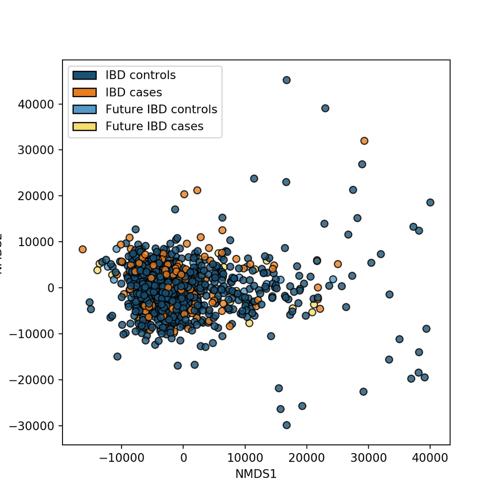

```python
handles = [Patch(facecolor=colors[color], edgecolor='k', label='') for color in colors]
plt.legend(handles=handles, labels=labels, loc='upper left')
```

### Bray-Curtis relative abundance

Converted from read counts to relative abundance

```python
metadata = pd.read_csv(metadata_fn, index_col=0, header=0)
ft_ra = ft_red.divide(ft_red.sum(axis=0), axis=1).multiply(100)

if os.path.exists(save_path+'npos_bc_ra.df'):
  with open(save_path+'npos_bc_ra.df', 'rb') as f: npos_bc_ra = pickle.load(f)
else:
  pos, npos_bc_ra, stress = transform_for_NMDS(ft_ra.transpose())
  with open(save_path+'npos_bc_ra.df', 'wb') as f: pickle.dump(npos_bc_ra, f)

npos = npos_bc_ra
plt.figure(figsize=(6,6))
colors = {'IBD0':'#1A5276', 'IBD1':'#E67E22', 'FUTURE_IBD0':'#5499C7', 'FUTURE_IBD1':'#F7DC6F'}
labels = ['IBD controls', 'IBD cases', 'Future IBD controls', 'Future IBD cases']
sample_names = list(ft_ra.columns)
for a in range(len(sample_names)):
  g1, g2 = metadata.loc[sample_names[a], 'GROUP'], metadata.loc[sample_names[a], 'CASE_CONTROL']
  if not isinstance(g1, str): g1, g2 = g1[0], g2[0]
  color = colors[str(g1)+str(g2)]
  plt.scatter(npos[a,0], npos[a,1], color=color, edgecolor='k', alpha=0.8)
plt.xlabel('NMDS1'), plt.ylabel('NMDS2')
```

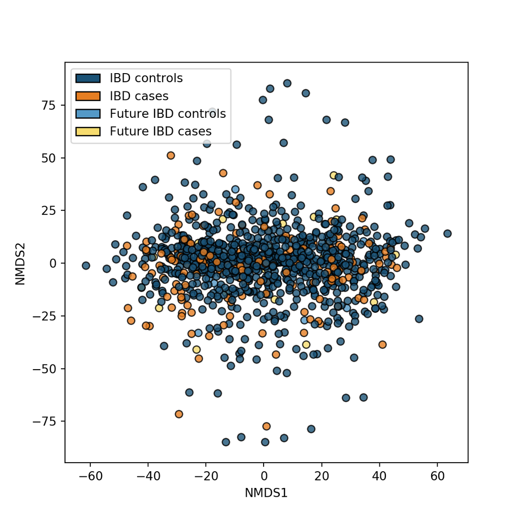

```python
handles = [Patch(facecolor=colors[color], edgecolor='k', label='') for color in colors]
plt.legend(handles=handles, labels=labels, loc='upper left')
```

### Aitchison distance (Euclidean on CLR)

Convert to CLR:

```r
asv_table <- py$ft_red
asv_table = as.matrix(asv_table)
phy_tree <- read_tree("/Users/robynwright/Documents/OneDrive/Langille_Lab_postdoc/AtPATH_IBD/exports/tree.nwk")

#Convert these to phyloseq objects
ASV = otu_table(asv_table, taxa_are_rows = TRUE)
physeq = phyloseq(ASV,phy_tree)

physeq_clr <- microbiome::transform(physeq, "clr")
write_phyloseq(physeq_clr, type="all", path=py$save_path)
```

Plot:

```python
metadata = pd.read_csv(metadata_fn, index_col=0, header=0)
ft_clr_fn = '/Users/robynwright/Documents/OneDrive/Langille_Lab_postdoc/AtPATH_IBD/analysis/otu_table.csv'
ft_clr = pd.read_csv(ft_clr_fn, index_col=0, header=0)

if os.path.exists(save_path+'npos_eu_clr.df'):
  with open(save_path+'npos_eu_clr.df', 'rb') as f: npos_eu_clr = pickle.load(f)
else:
  pos, npos_eu_clr, stress = transform_for_NMDS(ft_clr.transpose(), dist_met='euclidean')
  with open(save_path+'npos_eu_clr.df', 'wb') as f: pickle.dump(npos_eu_clr, f)

npos = npos_eu_clr

plt.figure(figsize=(6,6))
colors = {'IBD0':'#1A5276', 'IBD1':'#E67E22', 'FUTURE_IBD0':'#5499C7', 'FUTURE_IBD1':'#F7DC6F'}
labels = ['IBD controls', 'IBD cases', 'Future IBD controls', 'Future IBD cases']
sample_names = list(ft_clr.columns)
for a in range(len(sample_names)):
  g1, g2 = metadata.loc[sample_names[a], 'GROUP'], metadata.loc[sample_names[a], 'CASE_CONTROL']
  if not isinstance(g1, str): g1, g2 = g1[0], g2[0]
  color = colors[str(g1)+str(g2)]
  plt.scatter(npos[a,0], npos[a,1], color=color, edgecolor='k', alpha=0.8)
plt.xlabel('NMDS1'), plt.ylabel('NMDS2')
```

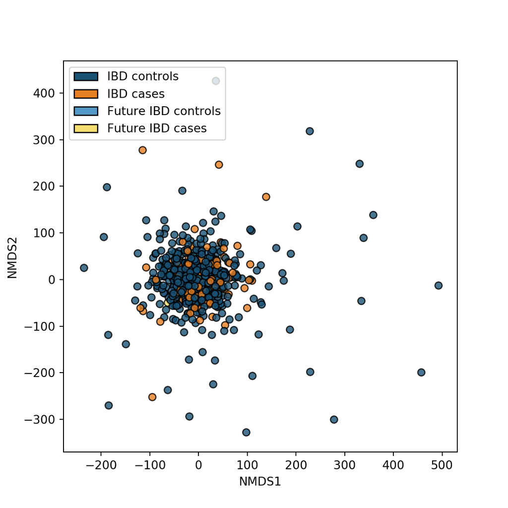

```python
handles = [Patch(facecolor=colors[color], edgecolor='k', label='') for color in colors]
plt.legend(handles=handles, labels=labels, loc='upper left')
```

### PHILR distance

Make taxonomy matrix:

```python
tax = pd.DataFrame(pd.read_csv(ft_fn, index_col=0, header=0).loc[:, 'taxonomy'])
levels = ["Domain", "Phylum", "Class", "Order", "Family", "Genus", "Species"]
for level in levels:
  tax[level] = ''

for row in tax.index.values:
  this_tax = tax.loc[row, 'taxonomy']
  this_tax = this_tax.split(';')
  for a in range(len(this_tax)):
    tax.loc[row, levels[a]] = this_tax[a].split('__')[1]

tax = tax.drop('taxonomy', axis=1)
tax = tax.reset_index()
tax = tax.rename(columns={'#OTU ID':'OTUID'})
```

Calculate:

```r
asv_table <- py$ft_red
asv_table = as.matrix(asv_table)
taxmat <- py$tax
taxmat2 <- taxmat[,-1]
rownames(taxmat2) <- taxmat[,1]
sampledata <- py$metadata
sampledata <- sample_data(sampledata)
colnames(taxmat2) <- c("Domain", "Phylum", "Class", "Order", "Family", "Genus", "Species")
phy_tree <- read_tree("/Users/robynwright/Documents/OneDrive/Langille_Lab_postdoc/AtPATH_IBD/exports/tree.nwk")

#Convert these to phyloseq objects
ASV = otu_table(asv_table, taxa_are_rows = TRUE)
TAX = tax_table(taxmat2)
taxa_names(TAX) <- taxmat[,1]
physeq = phyloseq(ASV,phy_tree,TAX, sampledata)

is.rooted(phy_tree(physeq))
is.binary.tree(phy_tree(physeq))
phy_tree(physeq) <- makeNodeLabel(phy_tree(physeq), method="number", prefix='n')
name.balance(phy_tree(physeq), tax_table(physeq), 'n1')

#Add pseudocount
physeq <- transform_sample_counts(physeq, function(x) x+1)

#now the philr part
otu.table <- t(otu_table(physeq))
tree <- phy_tree(physeq)
metadata <- sample_data(physeq)
tax <- tax_table(physeq)
physeq.philr <- philr(otu.table, tree, part.weights='enorm.x.gm.counts', ilr.weights='blw.sqrt')
physeq.philr.mat = as.matrix(physeq.philr)

#now calculate the distance
physeq.dist <- dist(physeq.philr, method="euclidean")
physeq.dist.mat <- as.matrix(physeq.dist)
write.csv(physeq.dist.mat, paste(py$save_path, "philr_distance.csv", sep=""))
```

Plot:

```python
metadata = pd.read_csv(metadata_fn, index_col=0, header=0)
ft_philr_fn = '/Users/robynwright/Documents/OneDrive/Langille_Lab_postdoc/AtPATH_IBD/analysis/philr_distance.csv'
ft_philr = pd.read_csv(ft_philr_fn, header=0, index_col=0)

if os.path.exists(save_path+'npos_philr.df'):
  with open(save_path+'npos_philr.df', 'rb') as f: npos_philr = pickle.load(f)
else:
  pos, npos_philr, stress = transform_for_NMDS(ft_philr.transpose(), dist_met=False)
  with open(save_path+'npos_philr.df', 'wb') as f: pickle.dump(npos_philr, f)

npos = npos_philr
plt.figure(figsize=(6,6))
colors = {'IBD0':'#1A5276', 'IBD1':'#E67E22', 'FUTURE_IBD0':'#5499C7', 'FUTURE_IBD1':'#F7DC6F'}
labels = ['IBD controls', 'IBD cases', 'Future IBD controls', 'Future IBD cases']
sample_names = list(ft_philr.columns)
for a in range(len(sample_names)):
  g1, g2 = metadata.loc[sample_names[a], 'GROUP'], metadata.loc[sample_names[a], 'CASE_CONTROL']
  if not isinstance(g1, str): g1, g2 = g1[0], g2[0]
  color = colors[str(g1)+str(g2)]
  plt.scatter(npos[a,0], npos[a,1], color=color, edgecolor='k', alpha=0.8)
plt.xlabel('NMDS1'), plt.ylabel('NMDS2')
```

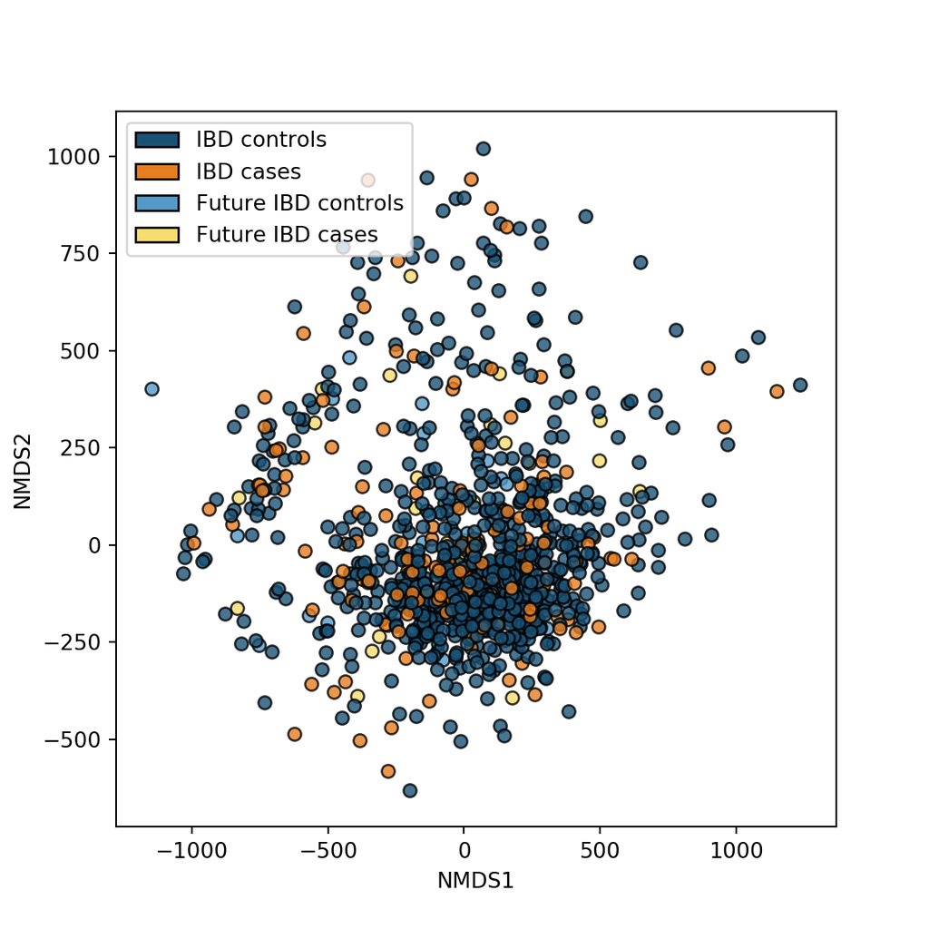

```python
handles = [Patch(facecolor=colors[color], edgecolor='k', label='') for color in colors]
plt.legend(handles=handles, labels=labels, loc='upper left')
```

## Taxa bar plots

Just regular bar plots at different levels

## Heat maps

Showing samples ordered by some distance metric and abundance of taxa (genus level?) within the samples

# Differential abundance

ANCOM

# Random Forests

Run for lots of different categories and at different levels

## Healthy/Future IBD/IBD

## Age

## Sex

## Diet

## etc

# Combine differential abundance and random forest